# Risk Factor Analysis

## Outcome Variable

**Outcome Variable:** stunted

## Predictor Variables

**Intervention Variable:** cleanck

**Adjustment Set:**

unadjusted

## Stratifying Variables

The analysis was stratified on these variable(s):

- agecat
- studyid
- country

## Data Summary

| agecat | studyid | country | cleanck | stunted | n_cell | n |
| --- | --- | --- | --- | --- | --- | --- |
| Birth | ki0047075b-MAL-ED | PERU | 0 | 0 | 1 | 2 |
| Birth | ki0047075b-MAL-ED | PERU | 1 | 0 | 1 | 2 |
| Birth | ki0047075b-MAL-ED | SOUTH AFRICA | 0 | 0 | 1 | 2 |
| Birth | ki0047075b-MAL-ED | SOUTH AFRICA | 0 | 1 | 0 | 2 |
| Birth | ki0047075b-MAL-ED | SOUTH AFRICA | 1 | 0 | 0 | 2 |
| Birth | ki0047075b-MAL-ED | SOUTH AFRICA | 1 | 1 | 1 | 2 |
| 6 months | ki0047075b-MAL-ED | SOUTH AFRICA | 1 | 0 | 1 | 1 |
| 24 months | ki0047075b-MAL-ED | SOUTH AFRICA | 1 | 0 | 1 | 1 |
| 6 months | ki1000108-CMC-V-BCS-2002 | INDIA | 0 | 0 | 135 | 369 |
| 6 months | ki1000108-CMC-V-BCS-2002 | INDIA | 0 | 1 | 71 | 369 |
| 6 months | ki1000108-CMC-V-BCS-2002 | INDIA | 1 | 0 | 123 | 369 |
| 6 months | ki1000108-CMC-V-BCS-2002 | INDIA | 1 | 1 | 40 | 369 |
| 24 months | ki1000108-CMC-V-BCS-2002 | INDIA | 0 | 0 | 39 | 372 |
| 24 months | ki1000108-CMC-V-BCS-2002 | INDIA | 0 | 1 | 170 | 372 |
| 24 months | ki1000108-CMC-V-BCS-2002 | INDIA | 1 | 0 | 67 | 372 |
| 24 months | ki1000108-CMC-V-BCS-2002 | INDIA | 1 | 1 | 96 | 372 |
| Birth | ki1000108-CMC-V-BCS-2002 | INDIA | 0 | 0 | 40 | 90 |
| Birth | ki1000108-CMC-V-BCS-2002 | INDIA | 0 | 1 | 12 | 90 |
| Birth | ki1000108-CMC-V-BCS-2002 | INDIA | 1 | 0 | 34 | 90 |
| Birth | ki1000108-CMC-V-BCS-2002 | INDIA | 1 | 1 | 4 | 90 |
| 6 months | ki1000108-IRC | INDIA | 0 | 0 | 119 | 398 |
| 6 months | ki1000108-IRC | INDIA | 0 | 1 | 49 | 398 |
| 6 months | ki1000108-IRC | INDIA | 1 | 0 | 181 | 398 |
| 6 months | ki1000108-IRC | INDIA | 1 | 1 | 49 | 398 |
| 24 months | ki1000108-IRC | INDIA | 0 | 0 | 89 | 400 |
| 24 months | ki1000108-IRC | INDIA | 0 | 1 | 80 | 400 |
| 24 months | ki1000108-IRC | INDIA | 1 | 0 | 144 | 400 |
| 24 months | ki1000108-IRC | INDIA | 1 | 1 | 87 | 400 |
| Birth | ki1000108-IRC | INDIA | 0 | 0 | 138 | 378 |
| Birth | ki1000108-IRC | INDIA | 0 | 1 | 22 | 378 |
| Birth | ki1000108-IRC | INDIA | 1 | 0 | 197 | 378 |
| Birth | ki1000108-IRC | INDIA | 1 | 1 | 21 | 378 |
| 6 months | ki1017093b-PROVIDE | BANGLADESH | 0 | 0 | 76 | 583 |
| 6 months | ki1017093b-PROVIDE | BANGLADESH | 0 | 1 | 25 | 583 |
| 6 months | ki1017093b-PROVIDE | BANGLADESH | 1 | 0 | 413 | 583 |
| 6 months | ki1017093b-PROVIDE | BANGLADESH | 1 | 1 | 69 | 583 |
| 24 months | ki1017093b-PROVIDE | BANGLADESH | 0 | 0 | 49 | 577 |
| 24 months | ki1017093b-PROVIDE | BANGLADESH | 0 | 1 | 49 | 577 |
| 24 months | ki1017093b-PROVIDE | BANGLADESH | 1 | 0 | 338 | 577 |
| 24 months | ki1017093b-PROVIDE | BANGLADESH | 1 | 1 | 141 | 577 |
| Birth | ki1017093c-NIH-Crypto | BANGLADESH | 0 | 0 | 6 | 20 |
| Birth | ki1017093c-NIH-Crypto | BANGLADESH | 0 | 1 | 2 | 20 |
| Birth | ki1017093c-NIH-Crypto | BANGLADESH | 1 | 0 | 11 | 20 |
| Birth | ki1017093c-NIH-Crypto | BANGLADESH | 1 | 1 | 1 | 20 |
| 6 months | ki1017093c-NIH-Crypto | BANGLADESH | 0 | 0 | 179 | 545 |
| 6 months | ki1017093c-NIH-Crypto | BANGLADESH | 0 | 1 | 37 | 545 |
| 6 months | ki1017093c-NIH-Crypto | BANGLADESH | 1 | 0 | 264 | 545 |
| 6 months | ki1017093c-NIH-Crypto | BANGLADESH | 1 | 1 | 65 | 545 |
| 24 months | ki1017093c-NIH-Crypto | BANGLADESH | 0 | 0 | 167 | 410 |
| 24 months | ki1017093c-NIH-Crypto | BANGLADESH | 0 | 1 | 44 | 410 |
| 24 months | ki1017093c-NIH-Crypto | BANGLADESH | 1 | 0 | 156 | 410 |
| 24 months | ki1017093c-NIH-Crypto | BANGLADESH | 1 | 1 | 43 | 410 |
| 6 months | ki1113344-GMS-Nepal | NEPAL | 0 | 0 | 389 | 504 |
| 6 months | ki1113344-GMS-Nepal | NEPAL | 0 | 1 | 107 | 504 |
| 6 months | ki1113344-GMS-Nepal | NEPAL | 1 | 0 | 8 | 504 |
| 6 months | ki1113344-GMS-Nepal | NEPAL | 1 | 1 | 0 | 504 |
| 24 months | ki1113344-GMS-Nepal | NEPAL | 0 | 0 | 237 | 446 |
| 24 months | ki1113344-GMS-Nepal | NEPAL | 0 | 1 | 202 | 446 |
| 24 months | ki1113344-GMS-Nepal | NEPAL | 1 | 0 | 7 | 446 |
| 24 months | ki1113344-GMS-Nepal | NEPAL | 1 | 1 | 0 | 446 |

The following strata were considered:

- agecat: 24 months, studyid: ki0047075b-MAL-ED, country: SOUTH AFRICA
- agecat: 24 months, studyid: ki1000108-CMC-V-BCS-2002, country: INDIA
- agecat: 24 months, studyid: ki1000108-IRC, country: INDIA
- agecat: 24 months, studyid: ki1017093b-PROVIDE, country: BANGLADESH
- agecat: 24 months, studyid: ki1017093c-NIH-Crypto, country: BANGLADESH
- agecat: 24 months, studyid: ki1113344-GMS-Nepal, country: NEPAL
- agecat: 6 months, studyid: ki0047075b-MAL-ED, country: SOUTH AFRICA
- agecat: 6 months, studyid: ki1000108-CMC-V-BCS-2002, country: INDIA
- agecat: 6 months, studyid: ki1000108-IRC, country: INDIA
- agecat: 6 months, studyid: ki1017093b-PROVIDE, country: BANGLADESH
- agecat: 6 months, studyid: ki1017093c-NIH-Crypto, country: BANGLADESH
- agecat: 6 months, studyid: ki1113344-GMS-Nepal, country: NEPAL
- agecat: Birth, studyid: ki0047075b-MAL-ED, country: PERU
- agecat: Birth, studyid: ki0047075b-MAL-ED, country: SOUTH AFRICA
- agecat: Birth, studyid: ki1000108-CMC-V-BCS-2002, country: INDIA
- agecat: Birth, studyid: ki1000108-IRC, country: INDIA
- agecat: Birth, studyid: ki1017093c-NIH-Crypto, country: BANGLADESH

### Dropped Strata

Some strata were dropped due to rare outcomes:

- agecat: Birth, studyid: ki0047075b-MAL-ED, country: PERU
- agecat: Birth, studyid: ki0047075b-MAL-ED, country: SOUTH AFRICA
- agecat: 6 months, studyid: ki0047075b-MAL-ED, country: SOUTH AFRICA
- agecat: 24 months, studyid: ki0047075b-MAL-ED, country: SOUTH AFRICA
- agecat: Birth, studyid: ki1000108-CMC-V-BCS-2002, country: INDIA
- agecat: Birth, studyid: ki1017093c-NIH-Crypto, country: BANGLADESH
- agecat: 6 months, studyid: ki1113344-GMS-Nepal, country: NEPAL
- agecat: 24 months, studyid: ki1113344-GMS-Nepal, country: NEPAL

## Methods Detail

We’re interested in the causal parameters $E[Y_a]$ for all values of $a \in \mathcal{A}$. These parameters represent the mean outcome if, possibly contrary to fact, we intervened to set all units to have $A=a$. Under the randomization and positivity assumptions, these are identified by the statistical parameters $\psi_a=E_W[E_{Y|A,W}(Y|A=a,W)]$. In addition, we’re interested in the mean of $Y$, $E[Y]$ under no intervention (the observed mean). We will estimate these parameters by using SuperLearner to fit the relevant likelihood factors – $E_{Y|A,W}(Y|A=a,W)$ and $p(A=a|W)$, and then updating our likelihood fit using a joint TMLE.

For unadjusted analyses ($W=\{\}$), initial likelihoods were estimated using Lrnr_glm to estimate the simple $E(Y|A)$ and Lrnr_mean to estimate $p(A)$. For adjusted analyses, a small library containing Lrnr_glmnet, Lrnr_xgboost, and Lrnr_mean was used.

Having estimated these parameters, we will then use the delta method to estimate relative risks and attributable risks relative to a prespecified baseline level of $A$.

# Results Detail

## Results Plots

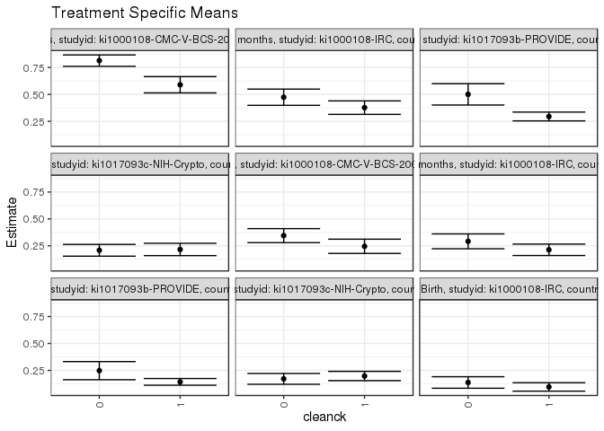

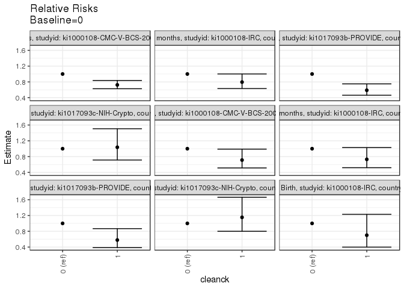

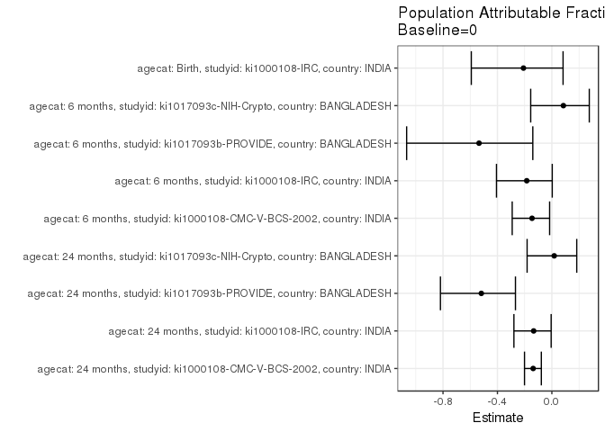

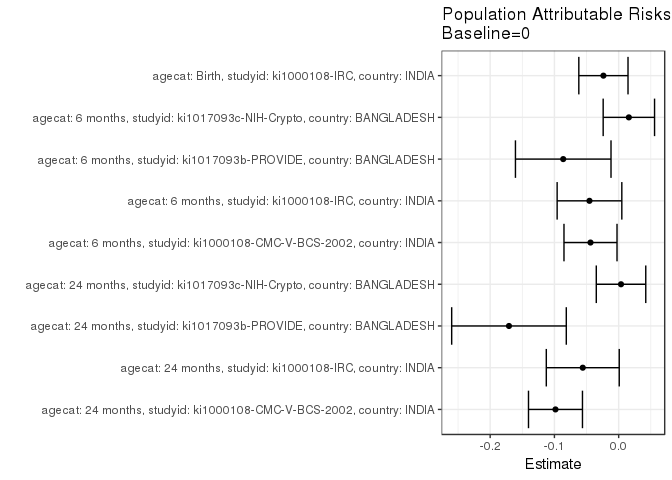

## Results Table

### Parameter: TSM

| agecat | studyid | country | intervention_level | baseline_level | estimate | ci_lower | ci_upper |
| --- | --- | --- | --- | --- | --- | --- | --- |
| Birth | ki1000108-IRC | INDIA | 0 | NA | 0.1375000 | 0.0840689 | 0.1909311 |
| Birth | ki1000108-IRC | INDIA | 1 | NA | 0.0963303 | 0.0571126 | 0.1355479 |
| 6 months | ki1000108-CMC-V-BCS-2002 | INDIA | 0 | NA | 0.3446602 | 0.2796723 | 0.4096481 |
| 6 months | ki1000108-CMC-V-BCS-2002 | INDIA | 1 | NA | 0.2453988 | 0.1792475 | 0.3115501 |
| 6 months | ki1000108-IRC | INDIA | 0 | NA | 0.2916667 | 0.2228487 | 0.3604847 |
| 6 months | ki1000108-IRC | INDIA | 1 | NA | 0.2130435 | 0.1600601 | 0.2660269 |
| 6 months | ki1017093b-PROVIDE | BANGLADESH | 0 | NA | 0.2475248 | 0.1632853 | 0.3317642 |
| 6 months | ki1017093b-PROVIDE | BANGLADESH | 1 | NA | 0.1431535 | 0.1118603 | 0.1744467 |
| 6 months | ki1017093c-NIH-Crypto | BANGLADESH | 0 | NA | 0.1712963 | 0.1210049 | 0.2215877 |
| 6 months | ki1017093c-NIH-Crypto | BANGLADESH | 1 | NA | 0.1975684 | 0.1545047 | 0.2406321 |
| 24 months | ki1000108-CMC-V-BCS-2002 | INDIA | 0 | NA | 0.8133971 | 0.7605076 | 0.8662867 |
| 24 months | ki1000108-CMC-V-BCS-2002 | INDIA | 1 | NA | 0.5889571 | 0.5133218 | 0.6645923 |
| 24 months | ki1000108-IRC | INDIA | 0 | NA | 0.4733728 | 0.3980022 | 0.5487433 |
| 24 months | ki1000108-IRC | INDIA | 1 | NA | 0.3766234 | 0.3140608 | 0.4391859 |
| 24 months | ki1017093b-PROVIDE | BANGLADESH | 0 | NA | 0.5000000 | 0.4009210 | 0.5990790 |
| 24 months | ki1017093b-PROVIDE | BANGLADESH | 1 | NA | 0.2943633 | 0.2535135 | 0.3352130 |
| 24 months | ki1017093c-NIH-Crypto | BANGLADESH | 0 | NA | 0.2085308 | 0.1536476 | 0.2634140 |
| 24 months | ki1017093c-NIH-Crypto | BANGLADESH | 1 | NA | 0.2160804 | 0.1588278 | 0.2733330 |

### Parameter: E(Y)

| agecat | studyid | country | intervention_level | baseline_level | estimate | ci_lower | ci_upper |
| --- | --- | --- | --- | --- | --- | --- | --- |
| Birth | ki1000108-IRC | INDIA | NA | NA | 0.1137566 | 0.0817056 | 0.1458077 |
| 6 months | ki1000108-CMC-V-BCS-2002 | INDIA | NA | NA | 0.3008130 | 0.2539566 | 0.3476694 |
| 6 months | ki1000108-IRC | INDIA | NA | NA | 0.2462312 | 0.2038529 | 0.2886094 |
| 6 months | ki1017093b-PROVIDE | BANGLADESH | NA | NA | 0.1612350 | 0.1313580 | 0.1911120 |
| 6 months | ki1017093c-NIH-Crypto | BANGLADESH | NA | NA | 0.1871560 | 0.1543801 | 0.2199318 |
| 24 months | ki1000108-CMC-V-BCS-2002 | INDIA | NA | NA | 0.7150538 | 0.6691221 | 0.7609854 |
| 24 months | ki1000108-IRC | INDIA | NA | NA | 0.4175000 | 0.3691120 | 0.4658880 |
| 24 months | ki1017093b-PROVIDE | BANGLADESH | NA | NA | 0.3292894 | 0.2909105 | 0.3676684 |
| 24 months | ki1017093c-NIH-Crypto | BANGLADESH | NA | NA | 0.2121951 | 0.1725707 | 0.2518196 |

### Parameter: RR

| agecat | studyid | country | intervention_level | baseline_level | estimate | ci_lower | ci_upper |
| --- | --- | --- | --- | --- | --- | --- | --- |
| Birth | ki1000108-IRC | INDIA | 0 | 0 | 1.0000000 | 1.0000000 | 1.0000000 |
| Birth | ki1000108-IRC | INDIA | 1 | 0 | 0.7005838 | 0.3990602 | 1.2299340 |
| 6 months | ki1000108-CMC-V-BCS-2002 | INDIA | 0 | 0 | 1.0000000 | 1.0000000 | 1.0000000 |
| 6 months | ki1000108-CMC-V-BCS-2002 | INDIA | 1 | 0 | 0.7120021 | 0.5124039 | 0.9893503 |
| 6 months | ki1000108-IRC | INDIA | 0 | 0 | 1.0000000 | 1.0000000 | 1.0000000 |
| 6 months | ki1000108-IRC | INDIA | 1 | 0 | 0.7304348 | 0.5184407 | 1.0291148 |
| 6 months | ki1017093b-PROVIDE | BANGLADESH | 0 | 0 | 1.0000000 | 1.0000000 | 1.0000000 |
| 6 months | ki1017093b-PROVIDE | BANGLADESH | 1 | 0 | 0.5783402 | 0.3859382 | 0.8666607 |
| 6 months | ki1017093c-NIH-Crypto | BANGLADESH | 0 | 0 | 1.0000000 | 1.0000000 | 1.0000000 |
| 6 months | ki1017093c-NIH-Crypto | BANGLADESH | 1 | 0 | 1.1533722 | 0.8001389 | 1.6625457 |
| 24 months | ki1000108-CMC-V-BCS-2002 | INDIA | 0 | 0 | 1.0000000 | 1.0000000 | 1.0000000 |
| 24 months | ki1000108-CMC-V-BCS-2002 | INDIA | 1 | 0 | 0.7240707 | 0.6269982 | 0.8361722 |
| 24 months | ki1000108-IRC | INDIA | 0 | 0 | 1.0000000 | 1.0000000 | 1.0000000 |
| 24 months | ki1000108-IRC | INDIA | 1 | 0 | 0.7956169 | 0.6320824 | 1.0014615 |
| 24 months | ki1017093b-PROVIDE | BANGLADESH | 0 | 0 | 1.0000000 | 1.0000000 | 1.0000000 |
| 24 months | ki1017093b-PROVIDE | BANGLADESH | 1 | 0 | 0.5887265 | 0.4622210 | 0.7498554 |
| 24 months | ki1017093c-NIH-Crypto | BANGLADESH | 0 | 0 | 1.0000000 | 1.0000000 | 1.0000000 |
| 24 months | ki1017093c-NIH-Crypto | BANGLADESH | 1 | 0 | 1.0362037 | 0.7132692 | 1.5053479 |

### Parameter: PAR

| agecat | studyid | country | intervention_level | baseline_level | estimate | ci_lower | ci_upper |
| --- | --- | --- | --- | --- | --- | --- | --- |
| Birth | ki1000108-IRC | INDIA | 0 | NA | -0.0237434 | -0.0620229 | 0.0145361 |
| 6 months | ki1000108-CMC-V-BCS-2002 | INDIA | 0 | NA | -0.0438472 | -0.0851190 | -0.0025754 |
| 6 months | ki1000108-IRC | INDIA | 0 | NA | -0.0454355 | -0.0957711 | 0.0049001 |
| 6 months | ki1017093b-PROVIDE | BANGLADESH | 0 | NA | -0.0862898 | -0.1606549 | -0.0119246 |
| 6 months | ki1017093c-NIH-Crypto | BANGLADESH | 0 | NA | 0.0158597 | -0.0241236 | 0.0558430 |
| 24 months | ki1000108-CMC-V-BCS-2002 | INDIA | 0 | NA | -0.0983434 | -0.1403411 | -0.0563456 |
| 24 months | ki1000108-IRC | INDIA | 0 | NA | -0.0558728 | -0.1126347 | 0.0008891 |
| 24 months | ki1017093b-PROVIDE | BANGLADESH | 0 | NA | -0.1707106 | -0.2599014 | -0.0815198 |
| 24 months | ki1017093c-NIH-Crypto | BANGLADESH | 0 | NA | 0.0036643 | -0.0348316 | 0.0421603 |

### Parameter: PAF

| agecat | studyid | country | intervention_level | baseline_level | estimate | ci_lower | ci_upper |
| --- | --- | --- | --- | --- | --- | --- | --- |
| Birth | ki1000108-IRC | INDIA | 0 | NA | -0.2087209 | -0.5920324 | 0.0823012 |
| 6 months | ki1000108-CMC-V-BCS-2002 | INDIA | 0 | NA | -0.1457623 | -0.2914859 | -0.0164812 |
| 6 months | ki1000108-IRC | INDIA | 0 | NA | -0.1845238 | -0.4069843 | 0.0027631 |
| 6 months | ki1017093b-PROVIDE | BANGLADESH | 0 | NA | -0.5351801 | -1.0672586 | -0.1400499 |
| 6 months | ki1017093c-NIH-Crypto | BANGLADESH | 0 | NA | 0.0847404 | -0.1555108 | 0.2750391 |
| 24 months | ki1000108-CMC-V-BCS-2002 | INDIA | 0 | NA | -0.1375328 | -0.2010248 | -0.0773973 |
| 24 months | ki1000108-IRC | INDIA | 0 | NA | -0.1338270 | -0.2788933 | -0.0052158 |
| 24 months | ki1017093b-PROVIDE | BANGLADESH | 0 | NA | -0.5184211 | -0.8188757 | -0.2675976 |
| 24 months | ki1017093c-NIH-Crypto | BANGLADESH | 0 | NA | 0.0172686 | -0.1819580 | 0.1829143 |